# imcarlyy_OriginalHomeworkCode_03

2025-03-01

#Guys, the theme that this HW was asking us to use didn’t work for me at all. I had to use a different one!

[figure not shown]

Zombie gif

# Some of my best friends are Zombies Homework

#Installing my packages:

## Reading my CSV zombie file:

```r
library(curl)
file_path <- curl("https://raw.githubusercontent.com/fuzzyatelin/fuzzyatelin.github.io/master/AN588_Fall23/zombies.csv")
survivors <- read.csv(file_path, header = TRUE, sep = ",", stringsAsFactors = FALSE)
```

> I think it might be simpler to use the {curl} package here. I couldn’t get this line to run on my computer, so I substituted in the curl method here.

## FIRST EXERCISE

### 1.1 Calculate the population mean for each quantitative random variable (height, weight, age, number of zombies killed, and years of education)

```r
#These are the quantitative random variables I got from my dataset.
height_mean <- mean(survivors$height)
weight_mean <- mean(survivors$weight)
age_mean <- mean(survivors$age)
zombies_killed_mean <- mean(survivors$zombies_killed)
years_of_education_mean <- mean(survivors$years_of_education)

print(paste("Population Mean of Height:", height_mean))
```

```
## [1] "Population Mean of Height: 67.63009808295"
```

```r
print(paste("Population Mean of Weight:", weight_mean))
```

```
## [1] "Population Mean of Weight: 143.90747819936"
```

```r
print(paste("Population Mean of Age:", age_mean))
```

```
## [1] "Population Mean of Age: 20.04696112212"
```

```r
print(paste("Population Mean of Zombies Killed:", zombies_killed_mean))
```

```
## [1] "Population Mean of Zombies Killed: 2.992"
```

```r
print(paste("Population Mean of Years of Education:", years_of_education_mean))
```

```
## [1] "Population Mean of Years of Education: 2.996"
```

### 1.2 Calculate the standard deviation for each quantitative random variable (height, weight, age, number of zombies killed, and years of education)

```r
height_sd_population <- sqrt(sum((survivors$height - height_mean)^2) / length(survivors$height))
weight_sd_population <- sqrt(sum((survivors$weight - weight_mean)^2) / length(survivors$weight))
age_sd_population <- sqrt(sum((survivors$age - age_mean)^2) / length(survivors$age))
zombies_killed_sd_population <- sqrt(sum((survivors$zombies_killed - zombies_killed_mean)^2) / length(survivors$zombies_killed))
years_of_education_sd_population <- sqrt(sum((survivors$years_of_education - years_of_education_mean)^2) / length(survivors$years_of_education))

print(paste("Population SD of Height:", height_sd_population))
```

```
## [1] "Population SD of Height: 4.30797010678797"
```

```r
print(paste("Population SD of Weight:", weight_sd_population))
```

```
## [1] "Population SD of Weight: 18.3918570867276"
```

```r
print(paste("Population SD of Age:", age_sd_population))
```

```
## [1] "Population SD of Age: 2.96358265176487"
```

```r
print(paste("Population SD of Zombies Killed:", zombies_killed_sd_population))
```

```
## [1] "Population SD of Zombies Killed: 1.74755142985836"
```

```r
print(paste("Population SD of Years of Education:", years_of_education_sd_population))
```

```
## [1] "Population SD of Years of Education: 1.67570403114631"
```

> These look good! As Soumalya mentioned to me, it’s good practice to save your results in a string or dataframe for future reference in addition to printing them.

## SECOND EXERCISE

### 2.1 Use {ggplot} to make boxplots of each of these variables by gender.

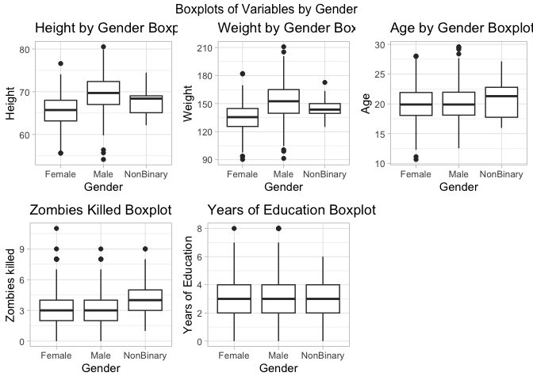

```r
library(ggplot2)
library(gridExtra)
survivors$gender <- as.factor(survivors$gender)


#This is my boxplot for height by gender
Height_plot <- ggplot(survivors, aes(x= gender, y=height)) + geom_boxplot() + labs(title= "Height by Gender Boxplot",x = "Gender", y= "Height") + theme_light()

#This is my boxplot for weight by gender
Weight_plot <- ggplot(survivors, aes(x=gender, y=weight)) + geom_boxplot() + labs(title="Weight by Gender Boxplot", x= "Gender", y= "Weight") + theme_light()

#This is my boxplot for age by gender
Age_plot<- ggplot(survivors, aes(x=gender, y=age)) + geom_boxplot() + labs(title= "Age by Gender Boxplot", x= "Gender", y= "Age") + theme_light()


#This is my boxplot for zombies killed by gender
Zombies_killed_plot <- ggplot(survivors, aes(x=gender, y=zombies_killed)) + geom_boxplot() + labs(title="Zombies Killed Boxplot", x= "Gender", y= "Zombies killed") + theme_light()

#This is my boxplot for Years of Education
Years_of_education_plot<- ggplot(survivors, aes(x=gender, y=years_of_education)) + geom_boxplot() + labs(title="Years of Education Boxplot", x= "Gender", y= "Years of Education") + theme_light()

#Here, I tell R that I want a 3x2 grid. Here, unlike with the patchwork package, I don't need to add an empty plot (I started working with that package before but it was too complicated and overwhelming so I switched to this other one).

#NOTE TO SELF: remember that the grid.arrage function comes from the gridExtra package.
grid.arrange(Height_plot, Weight_plot, Age_plot, Zombies_killed_plot, Years_of_education_plot, nrow = 2, ncol = 3, top = "Boxplots of Variables by Gender")
```

> I also used the gridExtra package! I like that you put a title on the grid–that didn’t occur to me to do.

## THIRD EXERCISE

### 3.1 Use {ggplot} to make scatterplots of height and weight in relation to age.

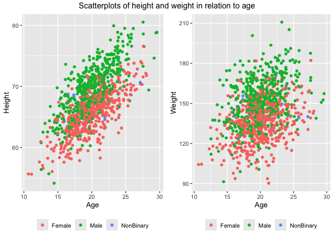

```r
height_scatterplot <- ggplot(data= survivors, aes(x= age, y= height, color= factor(gender))) + xlab("Age") + ylab("Height") + geom_point() + theme (legend.position = "bottom", legend.title = element_blank())

#This is the same that we did in Challenge 6, Module 6, but with some slight chances that make it easier to work with.
#This one took me a long time to figure out and I kept getting error messages because of a typo!

weight_scatterplot <- ggplot(data= survivors, aes(x= age, y= weight, color= factor(gender))) + xlab("Age") + ylab("Weight") + geom_point() + theme (legend.position = "bottom", legend.title = element_blank()) #This is the same that we did in Challenge 6, Module 6, but with some slight chances that make it easier to work with.

grid.arrange(height_scatterplot, weight_scatterplot, ncol=2, top= "Scatterplots of height and weight in relation to age") #It was very stasfying to learn about gridExtra because it made visualizing my plots much easier!
```

### 3.2 Do these variables seem to be related? In what way?

#MY ANSWER: In both scatterplots, it is visually evident that the height AND weight increase in relation to age. In spite of this, it is important to note that the height shows a more pronounced correlation with age compared to weight.

> It could be helpful to back up your analysis of the correlation by adding a regression line.